# **Agenda**

### Box plot

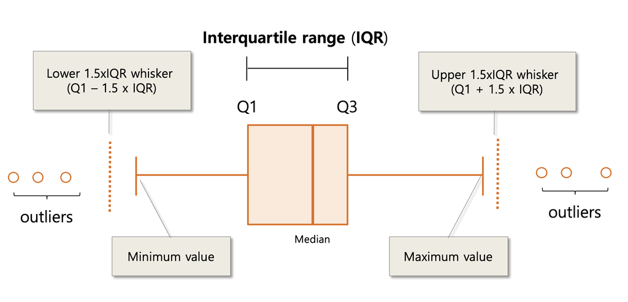

- Shows the distribution of quantitative data
- Seemedian, spread,skewness,andoutliers
- Facilitates comparisons between groups

```python
#loading data to practice
cars= sns.load_dataset("mpg")
cars.head()
```

|  | mpg | cylinders | displacement | horsepower | weight | acceleration | model_year | origin | name |
| --- | --- | --- | --- | --- | --- | --- | --- | --- | --- |
| 0 | 18.0 | 8 | 307.0 | 130.0 | 3504 | 12.0 | 70 | usa | chevrolet chevelle malibu |
| 1 | 15.0 | 8 | 350.0 | 165.0 | 3693 | 11.5 | 70 | usa | buick skylark 320 |
| 2 | 18.0 | 8 | 318.0 | 150.0 | 3436 | 11.0 | 70 | usa | plymouth satellite |
| 3 | 16.0 | 8 | 304.0 | 150.0 | 3433 | 12.0 | 70 | usa | amc rebel sst |
| 4 | 17.0 | 8 | 302.0 | 140.0 | 3449 | 10.5 | 70 | usa | ford torino |

```python
cars.shape
```

```
(398, 9)
```

```python
#cleaning data from nan vaules
cars=cars.dropna()
cars.shape
#we removed 6 nan vaules
```

```
(392, 9)
```

```python
#we will deal with cylinders column so we need to know the values of him
cars.cylinders.value_counts()
```

```
4    199
8    103
6     83
3      4
5      3
Name: cylinders, dtype: int64
```

```python
#as the odd number of cylinders is too low so we will agnore values
cars=cars[cars.cylinders.isin([4,6,8])]
cars.cylinders.value_counts()
```

```
4    199
8    103
6     83
Name: cylinders, dtype: int64
```

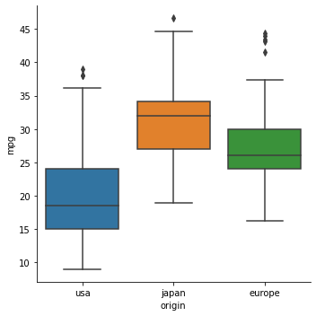

```python
# lets see how the cars consumption per galion (mpg)in each country (origin)
sns.catplot(x="origin",
       y="mpg",
       data=cars,
        kind="box")
```

**as we can see outliers we have good ways to deal with them**

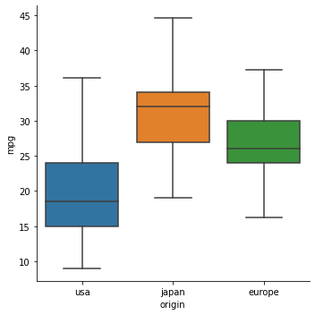

```python
# first is to remove them by "sym"= ""
sns.catplot(x="origin",
       y="mpg",
       data=cars,
        kind="box",
           sym="")
```

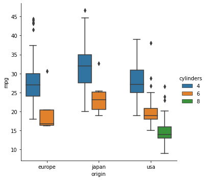

```python
# boxplot likes other Categorical plots in hue and order
sns.catplot(x="origin",
       y="mpg",
       data=cars,
        kind="box",
        hue="cylinders",
        order=["europe","japan","usa"])
```

#### second way to deal with outliers is by whiskers -----> whis

- By default, the whiskers extend to 1.5* the interquartile range
- we can change them to include outliers or include all vaules

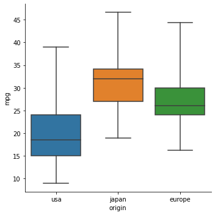

```python
# we change the whis to include the all data
sns.catplot(x="origin",
       y="mpg",
       data=cars,
        kind="box",
        whis=[0,100])
```

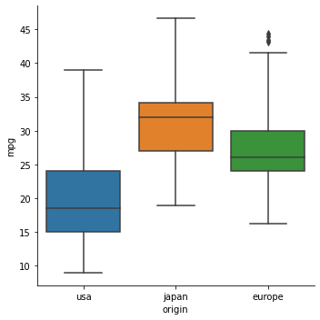

```python
# here we make them extand to 2.0 instead of 1.5 * IQR
sns.catplot(x="origin",
       y="mpg",
       data=cars,
        kind="box",
        whis=2.0)
```

### point plot

- Points show mean of quantitative variable
- Vertical lines show 95% condence intervals

### what is the differnce between point plot and line plot

**both show :**

- Mean of quantitative variable
- 95% condence interval sfor the mean

**Dierences:**

- Line plot has quantitative variable (usuallytime) on x-axis
- Point plot has categorical variable on x-axis

### what is the differnce between point plot and bar plot

**both show :**

- Points show mean of quantitative variable
- Vertical lines show 95% condence intervals

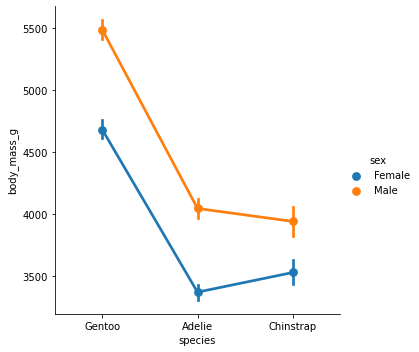

```python
sns.catplot(x="species",y="body_mass_g",
            data=penguins,
            kind="point",
            hue= "sex",
            hue_order=["Female","Male"],
            order=["Gentoo","Adelie","Chinstrap"])
```

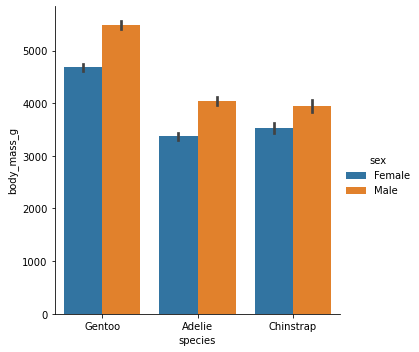

```python
sns.catplot(x="species",y="body_mass_g",
            data=penguins,
            kind="bar",
            hue= "sex",
            hue_order=["Female","Male"],
            order=["Gentoo","Adelie","Chinstrap"])
```

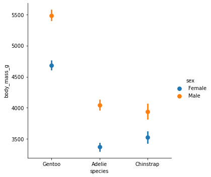

```python
# if we want to remove the lines conneted to the points ------> join = false
sns.catplot(x="species",y="body_mass_g",
            data=penguins,
            kind="point",
            hue= "sex",
            hue_order=["Female","Male"],
            join = False,
            order=["Gentoo","Adelie","Chinstrap"])
```

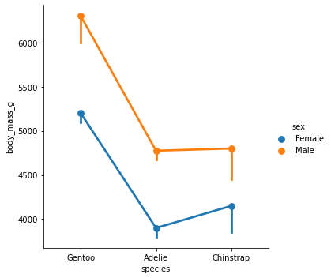

```python
# also we can use estimator like bar plot
sns.catplot(x="species",y="body_mass_g",
            data=penguins,
            kind="point",
            hue= "sex",
            hue_order=["Female","Male"],
            estimator= np.max,
            order=["Gentoo","Adelie","Chinstrap"])
```

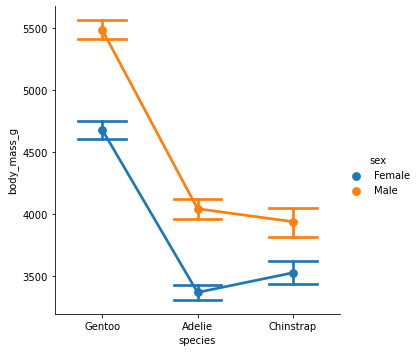

```python
# in box plot we has whis here we have capsize
sns.catplot(x="species",y="body_mass_g",
            data=penguins,
            kind="point",
            hue= "sex",
            hue_order=["Female","Male"],
            capsize= 0.5,
            order=["Gentoo","Adelie","Chinstrap"])
```

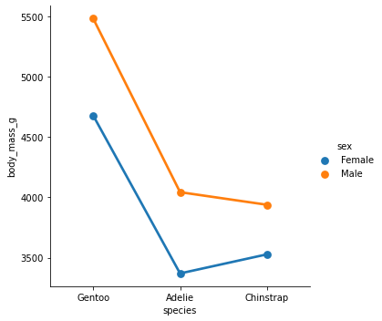

```python
# we also can remove ci with set ci = None
sns.catplot(x="species",y="body_mass_g",
            data=penguins,
            kind="point",
            hue= "sex",
            hue_order=["Female","Male"],
            ci=None,
            order=["Gentoo","Adelie","Chinstrap"])
```